# Lab9: SVM and Neural Networks

Ziping Xu

3/20/2020

## SVM

### Simulation data

Python `Sklearn.dataset` provides functions to generate simulated data for classification. I generaeted three simulated dataset using `make_moons(noise=0.3, random_state=0)`, `make_circles(noise=0.2, factor=0.5, random_state=1)` and `make_classification(n_features=2, n_redundant=0, n_informative=2, random_state=0, n_clusters_per_class=1)`. You may load them from `moons.csv`, `circle.csv`, and `linear_separable.csv`.

```r
set.seed(1)
library(plyr)
library(dplyr)
moons = read.csv("Simulated_data/moons.csv")
circle = read.csv("Simulated_data/circle.csv")
linear_separable = read.csv("Simulated_data/linear_separable.csv")

moons$type = "Moons"
circle$type = "Circle"
linear_separable$type = "Linear separable"

sim_dat = rbind.fill(moons, circle, linear_separable)
sim_dat$labels = as.factor(sim_dat$labels)
```

View the simulated data. We observe that Circle and Moons dataset are not linear separatable.

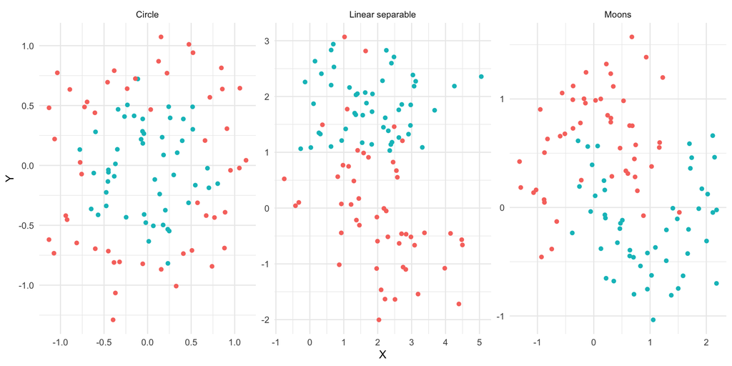

```r
library(ggplot2)
g = ggplot(sim_dat) + geom_point(aes(x = X, y = Y, color = labels)) + facet_wrap(.~type, scales = "free") + theme_minimal() + theme(legend.position = "None")
g
```

The `e1071` library gives implementations for a number of statistical learning methods. In particular, the `svm()` function can be used to fit a support vector classifier when the argument kernel=“linear” is used.

We now use the `svm()` function to fit the support vector classifier for a given value of the cost parameter. Here we demonstrate the use of this function on three simulated data and plot the resulting decision boundary.

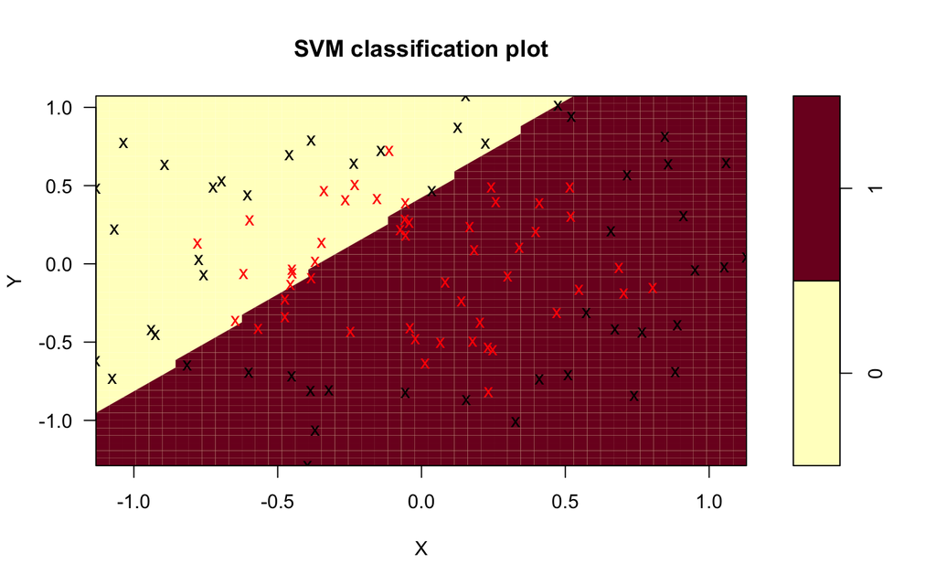

```r
library(e1071)

svmfit=svm(labels ~ X + Y, data=filter(sim_dat, type == "Circle"), kernel="linear", cost=1, scale=FALSE)
plot(svmfit,filter(sim_dat, type == "Circle"), Y ~ X)
```

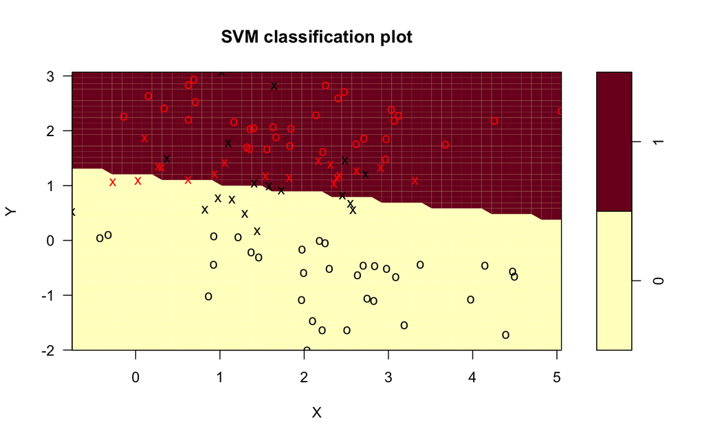

```r
svmfit=svm(labels ~ X + Y, data=filter(sim_dat, type == "Linear separable"), kernel="linear", cost=1, scale=FALSE)
plot(svmfit,filter(sim_dat, type == "Linear separable"), Y ~ X, main = "Linear separable")
```

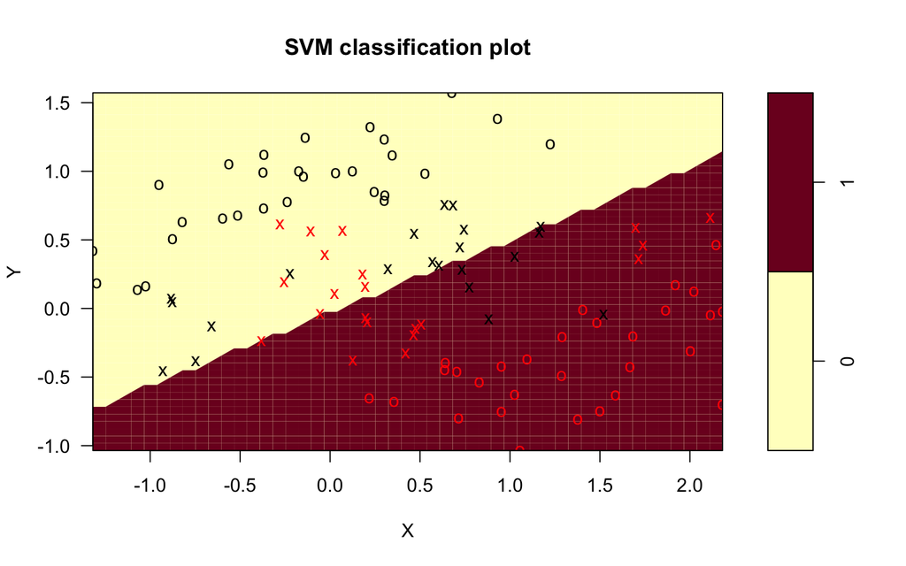

```r
svmfit=svm(labels ~ X + Y, data=filter(sim_dat, type == "Moons"), kernel="linear", cost=1, scale=FALSE)
plot(svmfit,filter(sim_dat, type == "Moons"), Y ~ X, main = "Moons")
```

The support vectors are plotted as crosses and the remaining observations are plotted as circles. A higher cost will give less support vectors.

We now try different kernels. To fit an SVM with a polynomial kernel we use kernel= `polynomial`, and to fit an SVM with a radial kernel we use kernel= `radial`. In the former case we also use the degree argument to specify a `degree` for the polynomial kernel, and in the latter case we use gamma to specify a value of $\gamma$ for the radial basis kernel.

The $d$-th polynomial kernel is defined as:
$$K(u, v) = (a u^T v + c)^{d}.$$
The radial kernel is defined as:
$$K(u, v)=\exp \left(-\gamma|| u-v||^{2}\right).$$

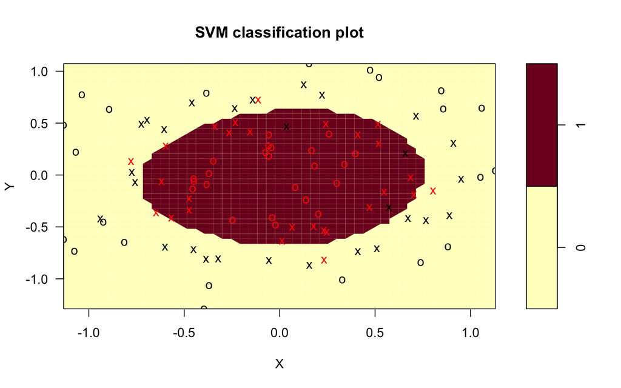

```r
svmfit=svm(labels ~ X + Y, data=filter(sim_dat, type == "Circle"), kernel="radial", gamma=1, cost=1, scale=FALSE)
plot(svmfit,filter(sim_dat, type == "Circle"), Y ~ X)
```

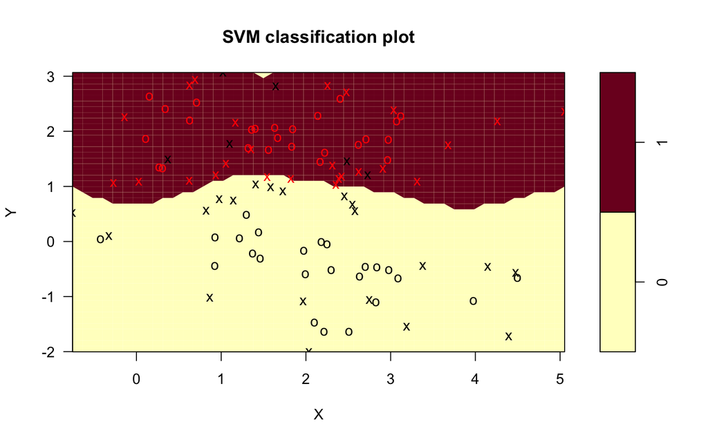

```r
svmfit=svm(labels ~ X + Y, data=filter(sim_dat, type == "Linear separable"), kernel="radial", gamma=1, cost=1, scale=FALSE)
plot(svmfit,filter(sim_dat, type == "Linear separable"), Y ~ X)
```

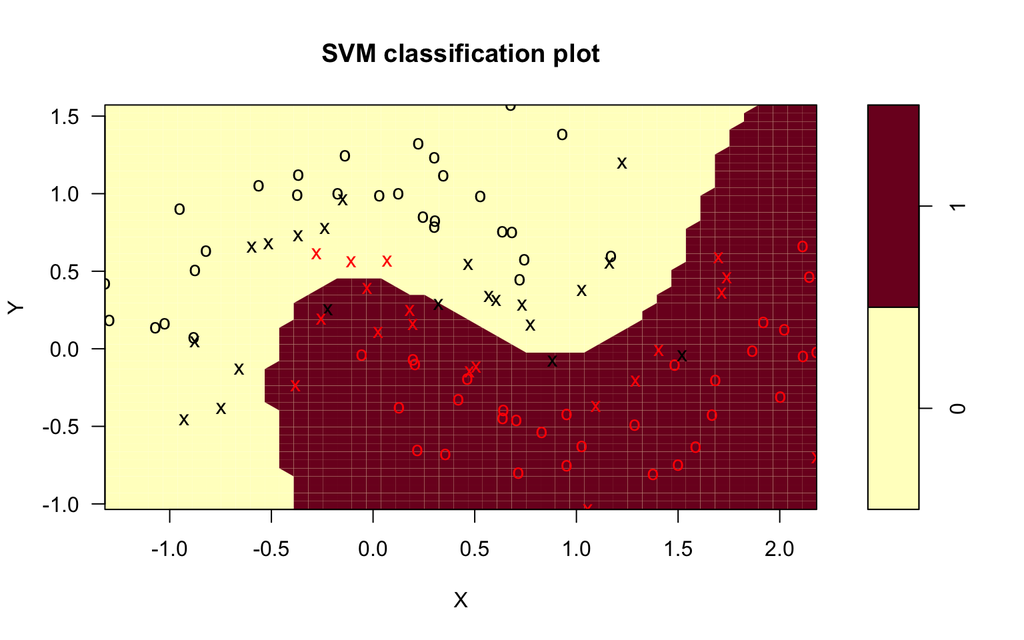

```r
svmfit=svm(labels ~ X + Y, data=filter(sim_dat, type == "Moons"), kernel="radial", gamma=1, cost=1, scale=FALSE)
plot(svmfit,filter(sim_dat, type == "Moons"), Y ~ X)
```

## Tune SVM on real data

This part uses the Fashion MNIST dataset which contains 70,000 grayscale images in 10 categories. The images show individual articles of clothing at low resolution (28 by 28 pixels), as seen here:

Fashion MNIST is intended as a drop-in replacement for the classic MNIST dataset—often used as the “Hello, World” of machine learning programs for computer vision. The MNIST dataset contains images of handwritten digits (0, 1, 2, etc) in an identical format to the articles of clothing we’ll use here.

[figure not shown]

Fashion

To load the data and prepare for the following modeling, we install the following packages. The Keras R interface uses the TensorFlow backend engine by default. To install both the core Keras library as well as the TensorFlow backend use the install_keras() function:

```r
#install.packages('devtools')
#devtools::install_github("rstudio/keras")
#devtools::install_github("rstudio/tensorflow")
#library(tensorflow)
#install_tensorflow(version = "1.12")

#library(keras)
#install_keras()
```

```r
library(keras)
fashion_mnist <- dataset_fashion_mnist()
c(train_images, train_labels) %<-% fashion_mnist$train
c(test_images, test_labels) %<-% fashion_mnist$test
```

At this point we have four arrays: The train_images and train_labels arrays are the training set — the data the model uses to learn. The model is tested against the test set: the test_images, and test_labels arrays.

The images each are 28 x 28 arrays, with pixel values ranging between 0 and 255. The labels are arrays of integers, ranging from 0 to 9. Each image is mapped to a single label. Since the class names are not included with the dataset, we’ll store them in a vector to use later when plotting the images.

```r
class_names = c('T-shirt/top',
                'Trouser',
                'Pullover',
                'Dress',
                'Coat',
                'Sandal',
                'Shirt',
                'Sneaker',
                'Bag',
                'Ankle boot')
```

### Explore the data

Let’s explore the format of the dataset before training the model. The following shows there are 60,000 images in the training set, with each image represented as 28 x 28 pixels. Each label is an integer between 0 and 9. There are 10,000 images in the test set. Again, each image is represented as 28 x 28 pixels.

```r
dim(train_images)
```

```
## [1] 60000    28    28
```

```r
dim(test_images)
```

```
## [1] 10000    28    28
```

```r
train_labels[1:20]
```

```
##  [1] 9 0 0 3 0 2 7 2 5 5 0 9 5 5 7 9 1 0 6 4
```

Display the first 25 images from the training set and display the class name below each image. Verify that the data is in the correct format and we’re ready to build and train the network.

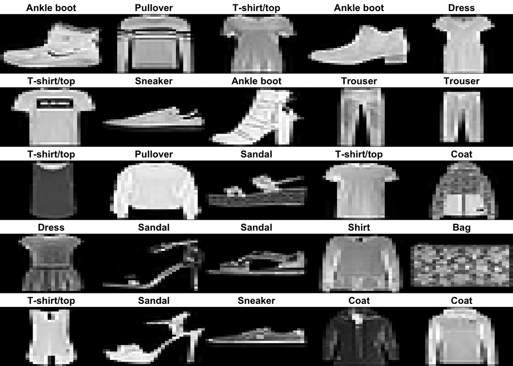

```r
par(mfcol=c(5,5))
par(mar=c(0, 0, 1.5, 0), xaxs='i', yaxs='i')
for (i in 1:25) {
  img <- train_images[i, , ]
  img <- t(apply(img, 2, rev))
  image(1:28, 1:28, img, col = gray((0:255)/255), xaxt = 'n', yaxt = 'n',
        main = paste(class_names[train_labels[i] + 1]))
}
```

### Preprocessing the data

We scale these values to a range of 0 to 1 before feeding to the model. For this, we simply divide by 255.

It’s important that the training set and the testing set are preprocessed in the same way:

```r
train_images <- train_images / 255
test_images <- test_images / 255
```

We further flatten the data from 2-dimention to a vector as input for SVM. Due to the time limit, we only train the first 1000 samples.

```r
train_images.1 <- matrix(train_images, dim(train_images)[1], prod(dim(train_images)[2:3]))
test_images.1 <- matrix(test_images, dim(test_images)[1], prod(dim(test_images)[2:3]))

train_labels = as.factor(train_labels)
test_labels = as.factor(test_labels)

train_dat = data.frame(train_labels[1:1000], train_images.1[1:1000, ])
colnames(train_dat)[1] = "labels"

test_dat = data.frame(test_labels, test_images.1)
colnames(test_dat)[1] = "labels"
```

### Tune SVM

`Tune` function allows us to search hyperparameter over a grid space. As performance measure, the classification error by cross-validation is used for classification.

```r
library(e1071)
tune.out =tune(svm, labels~., data=train_dat, ranges=list(cost=c(0.1,1,10,100), kernel=c("linear", "radial")))
summary(tune.out)
```

```
##
## Parameter tuning of 'svm':
##
## - sampling method: 10-fold cross validation
##
## - best parameters:
##  cost kernel
##    10 radial
##
## - best performance: 0.171
##
## - Detailed performance results:
##    cost kernel error dispersion
## 1   0.1 linear 0.174 0.04299871
## 2   1.0 linear 0.184 0.02503331
## 3  10.0 linear 0.183 0.02496664
## 4 100.0 linear 0.183 0.02496664
## 5   0.1 radial 0.593 0.07528465
## 6   1.0 radial 0.240 0.03915780
## 7  10.0 radial 0.171 0.02806738
## 8 100.0 radial 0.178 0.02485514
```

The best model is given by radial kernel with $C = 10$ in terms of the cross validation error. We then test the best model on test set.

```r
test_dat = data.frame(test_labels, test_images.1)
colnames(test_dat)[1] = "labels"
test_pred = predict(tune.out$best.model, newdata = test_dat)
table(test_pred, test_dat$labels)
```

```
##
## test_pred   0   1   2   3   4   5   6   7   8   9
##         0 827  15  16  71   1   0 227   0   3   1
##         1   5 923   1   9   3   0   2   0   2   0
##         2  14  13 627   5  81   0 131   0  19   0
##         3  42  40   8 851  69   3  37   0   4   1
##         4   2   5 202  17 728   0 112   0   2   0
##         5   7   0   0   1   2 857   2  53  19  26
##         6  88   3 138  42 109   2 471   0  29   0
##         7   0   0   0   0   0  88   0 866   9  46
##         8  15   1   8   4   7   3  18   0 911   1
##         9   0   0   0   0   0  47   0  81   2 925
```

```r
sum((test_pred != test_labels)) / dim(test_dat)[1]
```

```
## [1] 0.2014
```

## Neural Networks

### R interface to Keras

We formally introduce R interface to Keras. Keras is a high-level neural networks API developed with a focus on enabling fast experimentation. Keras has the following key features:

- Allows the same code to run on CPU or on GPU, seamlessly.
- User-friendly API which makes it easy to quickly prototype deep learning models.
- Built-in support for convolutional networks (for computer vision), recurrent networks (for sequence processing), and any combination of both.
- Supports arbitrary network architectures: multi-input or multi-output models, layer sharing, model sharing, etc. This means that Keras is appropriate for building essentially any deep learning model, from a memory network to a neural Turing machine.
- Is capable of running on top of multiple back-ends including TensorFlow, CNTK, or Theano.

### Build MLP (Multi Layer Perception)

The basic building block of a neural network is the layer. Layers extract representations from the data fed into them. And, hopefully, these representations are more meaningful for the problem at hand.

Most of deep learning consists of chaining together simple layers. Most layers, like layer_dense, have parameters that are learned during training.

```r
model_fashion <- keras_model_sequential()
model_fashion %>%
  layer_flatten(input_shape = c(28, 28)) %>%
  layer_dense(units = 128, activation = 'relu') %>%
  layer_dense(units = 10, activation = 'softmax')
```

The first layer in this network, layer_flatten, transforms the format of the images from a 2d-array (of 28 by 28 pixels), to a 1d-array of 28 * 28 = 784 pixels. Think of this layer as unstacking rows of pixels in the image and lining them up. This layer has no parameters to learn; it only reformats the data.

After the pixels are flattened, the network consists of a sequence of two dense layers. These are densely-connected, or fully-connected, neural layers. The first dense layer has 128 nodes (or neurons). The second (and last) layer is a 10-node softmax layer —this returns an array of 10 probability scores that sum to 1. Each node contains a score that indicates the probability that the current image belongs to one of the 10 digit classes.

### Compile the model

Before the model is ready for training, it needs a few more settings. These are added during the model’s compile step:

- Loss function — This measures how accurate the model is during training. We want to minimize this function to “steer” the model in the right direction. We use Crossentropy in the classification problem.
- Optimizer — This is how the model is updated based on the data it sees and its loss function. We use the popular `adam` optimizer.
- Metrics —Used to monitor the training and testing steps. The following example uses accuracy, the fraction of the images that are correctly classified.

```r
model_fashion %>% compile(
  optimizer = 'adam',
  loss = 'sparse_categorical_crossentropy',
  metrics = c('accuracy')
)
```

### Train the model

Training the neural network model requires the following steps:

- Feed the training data to the model — in this example, the train_images and train_labels arrays.
- The model learns to associate images and labels.
- We ask the model to make predictions about a test set — in this example, the test_images array. We verify that the predictions match the labels from the test_labels array.

To start training, call the fit method — the model is “fit” to the training data. Since `Keras` does not accept `factor` labels, we first transform them back to matrix.

```r
train_labels = as.matrix(train_labels)
test_labels = as.matrix(test_labels)
MLP.history = model_fashion %>% fit(train_images, train_labels, epochs = 30, validation_split = 0.2, batch_size = 32)
```

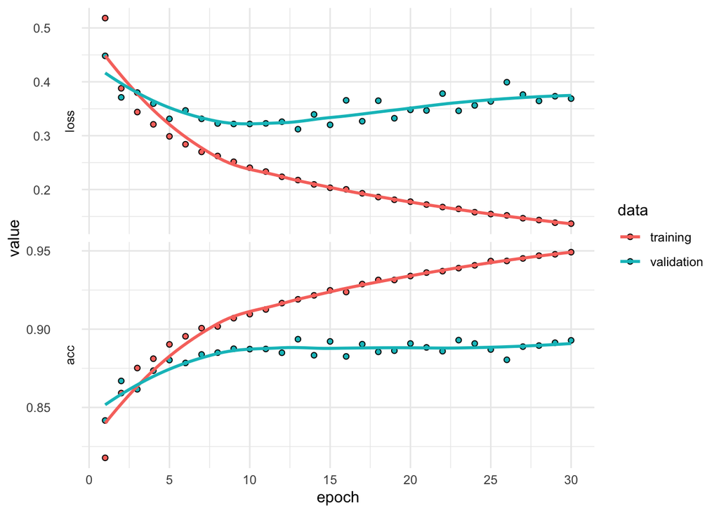

```r
plot(MLP.history) + theme_minimal()
```

The mode has strong overfitting. There are multiple ways to solve the problem. One way is to early stop training process and only test all the models with lowest validation loss and end training process.

### Evaluate accuracy

Next, compare how the model performs on the test dataset:

```r
score <- model_fashion %>% evaluate(test_images, test_labels)

cat('Test loss:', score$loss, "\n")
```

```
## Test loss: 0.4093967
```

```r
cat('Test accuracy:', score$acc, "\n")
```

```
## Test accuracy: 0.8864
```

### Build CNN model

CNN model has been shown to have good performance inimage classification tasks. We now implement the CNN using Keras. We will also breifly cover some training tricks in Deep Learning. We first define a CNN with two convolutionary layer and one hidden fully connected layer. This model with three layers is even more complex than MLP. We introduce Dropout layer to constraint fitting in the training process. Dropout layer disables part of connections according to `rate` to avoid overfiting.

```r
model_fashion.cnn <- keras_model_sequential()
#configuring the Model
model_fashion.cnn %>%
#defining a 2-D convolution layer

layer_conv_2d(filter=32,kernel_size=c(3,3),padding="same",input_shape=c(28,28, 1) ) %>%  layer_activation("relu") %>%
layer_max_pooling_2d(pool_size=c(2,2)) %>%
#another 2-D convolution layer
layer_conv_2d(filter=32 ,kernel_size=c(3,3))  %>%  layer_activation("relu") %>%
#Defining a Pooling layer which reduces the dimentions of the #features map and reduces the computational complexity of the model
layer_max_pooling_2d(pool_size=c(2,2)) %>%
#dropout layer to avoid overfitting
layer_dropout(0.25) %>%
#flatten the input
layer_flatten() %>%
layer_dense(64) %>%
layer_activation("relu") %>%
layer_dropout(0.5) %>%
#output layer-10 classes-10 units
layer_dense(10) %>%
#applying softmax nonlinear activation function to the output layer #to calculate cross-entropy
layer_activation("softmax")
```

2D convolution requires a 4D input tensor. We first add an extra axis on our training and testing dataset.

```r
train_images.cnn = array(train_images, dim = c(dim(train_images)[1], dim(train_images)[2], dim(train_images)[3], 1))
test_images.cnn = array(test_images, dim = c(dim(test_images)[1], dim(test_images)[2], dim(test_images)[3], 1))
```

We use the same training setting.

```r
model_fashion.cnn %>% compile(
  optimizer = 'adam',
  loss = 'sparse_categorical_crossentropy',
  metrics = c('accuracy')
)
CNN.history = model_fashion.cnn %>% fit(train_images.cnn, train_labels, epochs = 30, validation_split = 0.2, batch_size = 32)
```

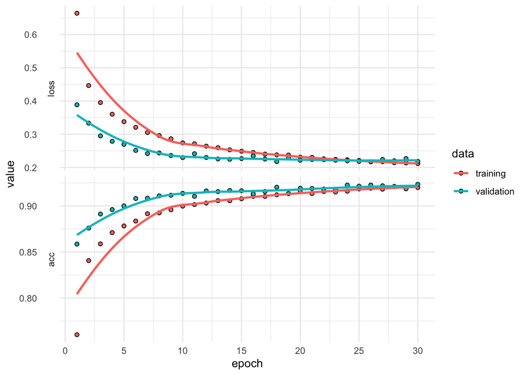

```r
plot(CNN.history) + theme_minimal()
```

Compared to the training process of MLP, CNN model with dropout has much lower discrepency between training error and validation error.

```r
score <- model_fashion.cnn %>% evaluate(test_images.cnn, test_labels)

cat('Test loss:', score$loss, "\n")
```

```
## Test loss: 0.2370346
```

```r
cat('Test accuracy:', score$acc, "\n")
```

```
## Test accuracy: 0.9193
```

There are much more hyperparameters that have a potential to train a better model including `learning rate`, `optimizer`, `batch size`, and parameter initialization.